# Brent Oil Price Forecasting

Coursework 1

Osaretin Daniel Agbonkpolor

Spring Term 2025

[output not shown]

# Introduction

I chose Brent Oil for my analysis because of its relevance, being that it serves as a reference price for $\frac{2}{3}$ of the world’s traded oil. I also lived in Bahrain for 7 years and had daily encounters with oil rigs and pipelines. The data set I’ll be using spans from 1987 to today, which provides a large record to look at, including the 2008 crash and effects of COVID-19 in 2020. Using tools I’ve learnt over my degree, I will identify trends and seasonal patterns in Brent oil prices, measure the impact of major global events on the volatility of Brent oil’s price, and use Prophet to do a 5-year forecast.

## Getting The Data

```r
getSymbols("DCOILBRENTEU", src = "FRED") # This is to get Brent oil from the federal reserve bank website
```

```
## [1] "DCOILBRENTEU"
```

```r
brent_oil <- DCOILBRENTEU # This names the Brent oil data from as 'Brent_oil'
brent_oil_df <- data.frame(ds = index(brent_oil),y = as.numeric(brent_oil$DCOILBRENTEU)) %>% na.omit() #this creates a data frame from the xts file because it isn't accepted by prophet, i also  removed all the 'N/A' values.
```

# 1 Brent Oil Price Analysis

## 1.1 Plotting the data

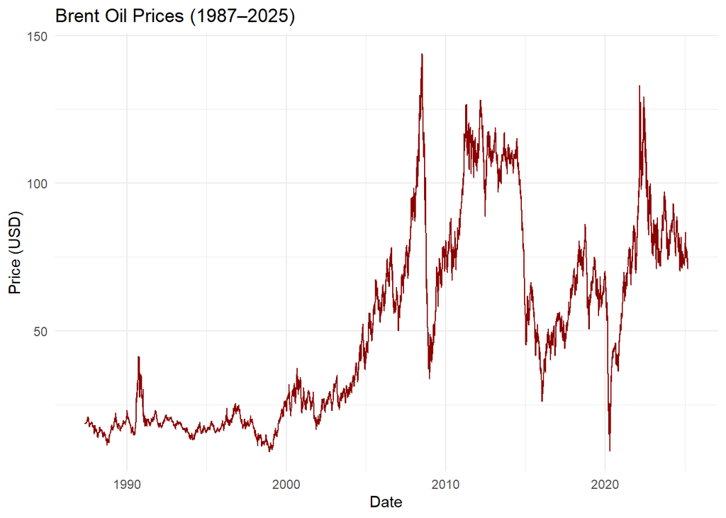

```r
# This creates a red line plot of Brent oil prices over time
ggplot(brent_oil_df, aes(x = ds, y = y)) +
  geom_line(color = "darkred") +
  labs(title = "Brent Oil Prices (1987–2025)", x = "Date", y = "Price (USD)") +
  theme_minimal()
```

## 1.2 Prophet Configuration (Seasonality)

```r
# gives 'model' intraweek and intrayear seasonality
model <- prophet(brent_oil_df, daily.seasonality = FALSE, weekly.seasonality = TRUE,yearly.seasonality = TRUE)
# This creates a future dataframe for forecasting 5 years (1825 days) ahead
five_years <- make_future_dataframe(model, periods = 1825, freq = "day")

# This generates a forecast using the fitted Prophet model
forecast <- predict(model, five_years)
print("figure 2")
```

```
## [1] "figure 2"
```

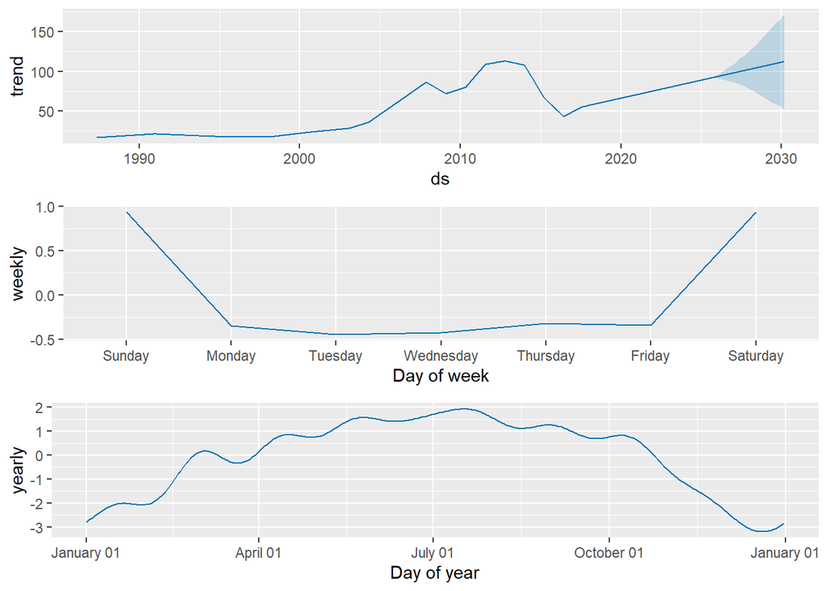

```r
# This splits forecast into components: trend, weekly/yearly seasonality, and residuals
prophet_plot_components(model, forecast)
```

### **1.2.1 Impact on Weekly Seasonality**

The apparent “increase” on weekends is likely because there is no data for those days or filling gaps with Friday’s price rather than the actual prices.

### **1.2.2 Impact on Yearly Seasonality**

I’ll talk about the trend in the next section.

## 1.3 Prophet Configuration (Trend & Forecast)

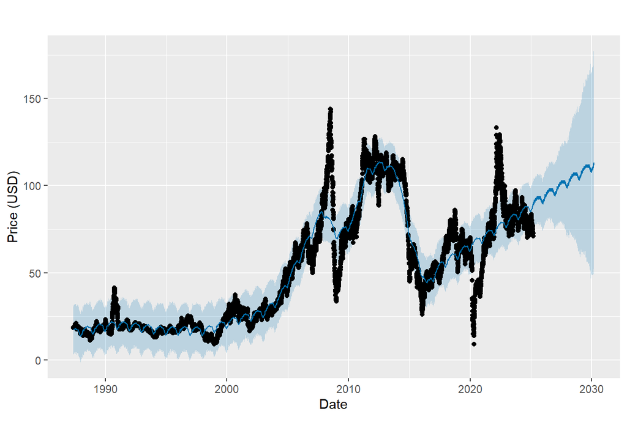

```r
plot(model, forecast,xlab="Date", ylab="Price (USD)")
```

Although Prophet catches long term trends and seasonality of Brent oil prices, there are several important economic elements which it does not sufficiently take into account. It does not predict sudden swings in price like what we saw in 2020, where the price dropped to $70/barrel to $20/barrel in a matter of weeks, or the 2008 financial crisis collapse from $140/barrel to $40/barrel. This is because it assumes gradual change based on historical data. The model also smooths over long volatile cycles, such as the 2014–2016 oil glut, which should be categorised as clusters of persistent risk rather than as random noise.